# **Encuentro Final – Conjunto de Datos de Indicadores de Salud de la Diabetes**

# Clase: Machine learning I

# **Integrantes Grupo (2 Personas):**

# - Daniel Santiago Gonzalez Citelly

# **1. Introducción**

## **1.1. Descripción del proyecto y su contexto.**

El proyecto se centra en la creciente necesidad de analizar datos de salud para prever y gestionar enfermedades crónicas como la diabetes. Utilizando tanto el conjunto de datos "Diabetes Health Indicators Dataset" de Kaggle como técnicas avanzadas de machine learning, se busca desarrollar un modelo que pueda predecir la probabilidad de diabetes en individuos. Este modelo no solo se basará en indicadores de salud, sino que también emplearán técnicas para comprender mejor la estructura de los datos y simplificar su representación. La detección temprana de la diabetes puede mejorar notablemente la calidad de vida de los pacientes y reducir los costos de atención médica, lo que resalta la importancia de este proyecto en el ámbito de la salud pública.

## **1.2. Objetivos del proyecto.**

### **Objetivo General**

El objetivo principal del proyecto es desarrollar un modelo de machine learning capaz de predecir la probabilidad de diabetes en individuos utilizando indicadores de salud. Además, se busca explorar técnicas para simplificar la representación de datos y mejorar la eficiencia del modelo. Los objetivos específicos incluyen:

### **Objetivos Específicos**

1. Realizar un análisis exploratorio de datos (EDA) para entender la distribución y relación entre las variables de salud.
2. Preparar y limpiar los datos para asegurar la calidad y consistencia del análisis, incluida la generación de conjuntos de entrenamiento y prueba.
3. Entrenar y evaluar modelos de machine learning para predecir la diabetes, incluyendo la comparación de modelos y la interpretación de resultados.
4. Identificar patrones de hábitos saludables y contrastarlos con la variable objetivo para entender mejor los factores de riesgo asociados con la diabetes.

# **2. Comprensión del Proyecto**

## **2.1. Identificación del objetivo del proyecto:**

El objetivo del proyecto es mejorar la capacidad de predecir y, por lo tanto, prevenir la diabetes a través del análisis de datos de indicadores de salud. Además de la predicción, se busca identificar patrones de hábitos y comportamientos relacionados con la salud que puedan ayudar en la prevención y gestión de la enfermedad.

## **2.3. Criterios de éxito:**

El éxito del proyecto se medirá mediante la capacidad del modelo para predecir correctamente la presencia de diabetes en los individuos, así como la identificación y comprensión de los factores de riesgo asociados. Además de la precisión y la eficacia del modelo, se valorará la interpretabilidad de los resultados y la utilidad práctica para los profesionales de la salud en la toma de decisiones informadas. Los criterios específicos incluyen:

**Precisión:** Porcentaje de predicciones correctas sobre el total de predicciones realizadas.

**Recall:** Capacidad del modelo para identificar correctamente a los individuos con diabetes.

**Métricas F1:** Combinación de precisión y recall para evaluar el balance entre ambas.

Siguiendo estos criterios, se busca desarrollar un modelo robusto que no solo tenga un alto rendimiento en términos de precisión, sino que también sea útil para los profesionales de la salud en la toma de decisiones informadas.

# **3. Comprensión de los Datos**

## 3.1. Recopilación y carga de datos.

```python
import pandas as pd
import matplotlib.pyplot as plt
import seaborn as sns
import numpy as np

from scipy import stats
from sklearn.pipeline import Pipeline
from sklearn.impute import SimpleImputer
from sklearn.preprocessing import StandardScaler,OneHotEncoder
from sklearn.compose import ColumnTransformer
from sklearn.ensemble import RandomForestClassifier
from sklearn.linear_model import LogisticRegression
from sklearn.svm import SVC
from sklearn.tree import DecisionTreeClassifier
from sklearn.neighbors import KNeighborsClassifier
from sklearn.exceptions import ConvergenceWarning
from sklearn.cluster import KMeans
from sklearn.model_selection import train_test_split
from xgboost import XGBClassifier
from imblearn.over_sampling import RandomOverSampler
from imblearn.under_sampling import RandomUnderSampler
from sklearn.metrics import accuracy_score, confusion_matrix, classification_report
from sklearn.model_selection import train_test_split, cross_val_score, GridSearchCV, RandomizedSearchCV

import warnings
```

```python
# Enlace al archivo CSV
link = 'https://docs.google.com/spreadsheets/d/e/2PACX-1vRBexGD3bu21aHIXe_POFy3JkDQnH_MPaEdQP7PYj9SthNPHM9mK4H71yCALth7rw-5VVvCsokgfCJS/pub?gid=944586614&single=true&output=csv'

# Especificamos el número de filas que deseamos leer
num_filas =  10000

# Leer solo las primeras 'num_filas' filas del archivo CSV
df = pd.read_csv(link, nrows=num_filas)

print("El dataset se ha cargado satisfactoriamente con", num_filas, "filas!")
```

```
El dataset se ha cargado satisfactoriamente con 10000 filas!
```

## 3.2. Análisis exploratorio de datos (EDA).

```python
df.head(15)
```

|  | Diabetes_012 | HighBP | HighChol | CholCheck | BMI | Smoker | Stroke | HeartDiseaseorAttack | PhysActivity | Fruits | ... | AnyHealthcare | NoDocbcCost | GenHlth | MentHlth | PhysHlth | DiffWalk | Sex | Age | Education | Income |
| --- | --- | --- | --- | --- | --- | --- | --- | --- | --- | --- | --- | --- | --- | --- | --- | --- | --- | --- | --- | --- | --- |
| 0 | 0.0 | 1.0 | 1.0 | 1.0 | 40.0 | 1.0 | 0.0 | 0.0 | 0.0 | 0.0 | ... | 1.0 | 0.0 | 5.0 | 18.0 | 15.0 | 1.0 | 0.0 | 9.0 | 4.0 | 3.0 |
| 1 | 0.0 | 0.0 | 0.0 | 0.0 | 25.0 | 1.0 | 0.0 | 0.0 | 1.0 | 0.0 | ... | 0.0 | 1.0 | 3.0 | 0.0 | 0.0 | 0.0 | 0.0 | 7.0 | 6.0 | 1.0 |
| 2 | 0.0 | 1.0 | 1.0 | 1.0 | 28.0 | 0.0 | 0.0 | 0.0 | 0.0 | 1.0 | ... | 1.0 | 1.0 | 5.0 | 30.0 | 30.0 | 1.0 | 0.0 | 9.0 | 4.0 | 8.0 |
| 3 | 0.0 | 1.0 | 0.0 | 1.0 | 27.0 | 0.0 | 0.0 | 0.0 | 1.0 | 1.0 | ... | 1.0 | 0.0 | 2.0 | 0.0 | 0.0 | 0.0 | 0.0 | 11.0 | 3.0 | 6.0 |
| 4 | 0.0 | 1.0 | 1.0 | 1.0 | 24.0 | 0.0 | 0.0 | 0.0 | 1.0 | 1.0 | ... | 1.0 | 0.0 | 2.0 | 3.0 | 0.0 | 0.0 | 0.0 | 11.0 | 5.0 | 4.0 |
| 5 | 0.0 | 1.0 | 1.0 | 1.0 | 25.0 | 1.0 | 0.0 | 0.0 | 1.0 | 1.0 | ... | 1.0 | 0.0 | 2.0 | 0.0 | 2.0 | 0.0 | 1.0 | 10.0 | 6.0 | 8.0 |
| 6 | 0.0 | 1.0 | 0.0 | 1.0 | 30.0 | 1.0 | 0.0 | 0.0 | 0.0 | 0.0 | ... | 1.0 | 0.0 | 3.0 | 0.0 | 14.0 | 0.0 | 0.0 | 9.0 | 6.0 | 7.0 |
| 7 | 0.0 | 1.0 | 1.0 | 1.0 | 25.0 | 1.0 | 0.0 | 0.0 | 1.0 | 0.0 | ... | 1.0 | 0.0 | 3.0 | 0.0 | 0.0 | 1.0 | 0.0 | 11.0 | 4.0 | 4.0 |
| 8 | 2.0 | 1.0 | 1.0 | 1.0 | 30.0 | 1.0 | 0.0 | 1.0 | 0.0 | 1.0 | ... | 1.0 | 0.0 | 5.0 | 30.0 | 30.0 | 1.0 | 0.0 | 9.0 | 5.0 | 1.0 |
| 9 | 0.0 | 0.0 | 0.0 | 1.0 | 24.0 | 0.0 | 0.0 | 0.0 | 0.0 | 0.0 | ... | 1.0 | 0.0 | 2.0 | 0.0 | 0.0 | 0.0 | 1.0 | 8.0 | 4.0 | 3.0 |
| 10 | 2.0 | 0.0 | 0.0 | 1.0 | 25.0 | 1.0 | 0.0 | 0.0 | 1.0 | 1.0 | ... | 1.0 | 0.0 | 3.0 | 0.0 | 0.0 | 0.0 | 1.0 | 13.0 | 6.0 | 8.0 |
| 11 | 0.0 | 1.0 | 1.0 | 1.0 | 34.0 | 1.0 | 0.0 | 0.0 | 0.0 | 1.0 | ... | 1.0 | 0.0 | 3.0 | 0.0 | 30.0 | 1.0 | 0.0 | 10.0 | 5.0 | 1.0 |
| 12 | 0.0 | 0.0 | 0.0 | 1.0 | 26.0 | 1.0 | 0.0 | 0.0 | 0.0 | 0.0 | ... | 1.0 | 0.0 | 3.0 | 0.0 | 15.0 | 0.0 | 0.0 | 7.0 | 5.0 | 7.0 |
| 13 | 2.0 | 1.0 | 1.0 | 1.0 | 28.0 | 0.0 | 0.0 | 0.0 | 0.0 | 0.0 | ... | 1.0 | 0.0 | 4.0 | 0.0 | 0.0 | 1.0 | 0.0 | 11.0 | 4.0 | 6.0 |
| 14 | 0.0 | 0.0 | 1.0 | 1.0 | 33.0 | 1.0 | 1.0 | 0.0 | 1.0 | 0.0 | ... | 1.0 | 1.0 | 4.0 | 30.0 | 28.0 | 0.0 | 0.0 | 4.0 | 6.0 | 2.0 |

15 rows × 22 columns

```python
link2 ="https://raw.githubusercontent.com/MeChaNiCox/atributos_ProyectoFinal_ML/main/variables_info.csv"
variables_info = pd.read_csv(link2)

print("Atributos del Dataset: ")
variables_info
```

```
Atributos del Dataset:
```

|  | Variable | Descripción |
| --- | --- | --- |
| 0 | Diabetes_012 | 0 = no diabetes 1 = prediabetes 2 = diabetes |
| 1 | HighBP | 0 = no high BP 1 = high BP |
| 2 | HighChol | 0 = no high cholesterol 1 = high cholesterol |
| 3 | CholCheck | 0 = no cholesterol check in 5 years 1 = yes ch... |
| 4 | BMI | Body Mass Index |
| 5 | Smoker | Have you smoked at least 100 cigarettes in you... |
| 6 | Stroke | (Ever told) you had a stroke. 0 = no 1 = yes |
| 7 | HeartDiseaseorAttack | coronary heart disease (CHD) or myocardial inf... |
| 8 | PhysActivity | physical activity in past 30 days - not includ... |
| 9 | Fruits | Consume Fruit 1 or more times per day 0 = no 1... |
| 10 | Veggies | Consume Vegetables 1 or more times per day 0 =... |
| 11 | HvyAlcoholConsump | Heavy drinkers (adult men having more than 14 ... |
| 12 | AnyHealthcare | Have any kind of health care coverage, includi... |
| 13 | NoDocbcCost | Was there a time in the past 12 months when yo... |
| 14 | GenHlth | Would you say that in general your health is: ... |
| 15 | MentHlth | Now thinking about your mental health, which i... |
| 16 | PhysHlth | Now thinking about your physical health, which... |
| 17 | DiffWalk | Do you have serious difficulty walking or clim... |
| 18 | Sex | 0 = female 1 = male |
| 19 | Age | 13-level age category (_AGEG5YR see codebook) ... |
| 20 | Education | Education level (EDUCA see codebook) scale 1-6... |
| 21 | Income | Income scale (INCOME2 see codebook) scale 1-8 ... |

```python
#(Filas, Columnas)
df.shape
```

```
(10000, 22)
```

```python
df.info()
```

```
<class 'pandas.core.frame.DataFrame'>
RangeIndex: 10000 entries, 0 to 9999
Data columns (total 22 columns):
 #   Column                Non-Null Count  Dtype
---  ------                --------------  -----
 0   Diabetes_012          10000 non-null  float64
 1   HighBP                10000 non-null  float64
 2   HighChol              10000 non-null  float64
 3   CholCheck             10000 non-null  float64
 4   BMI                   10000 non-null  float64
 5   Smoker                10000 non-null  float64
 6   Stroke                10000 non-null  float64
 7   HeartDiseaseorAttack  10000 non-null  float64
 8   PhysActivity          10000 non-null  float64
 9   Fruits                10000 non-null  float64
 10  Veggies               10000 non-null  float64
 11  HvyAlcoholConsump     10000 non-null  float64
 12  AnyHealthcare         10000 non-null  float64
 13  NoDocbcCost           10000 non-null  float64
 14  GenHlth               10000 non-null  float64
 15  MentHlth              10000 non-null  float64
 16  PhysHlth              10000 non-null  float64
 17  DiffWalk              10000 non-null  float64
 18  Sex                   10000 non-null  float64
 19  Age                   10000 non-null  float64
 20  Education             10000 non-null  float64
 21  Income                10000 non-null  float64
dtypes: float64(22)
memory usage: 1.7 MB
```

```python
df.columns
```

```
Index(['Diabetes_012', 'HighBP', 'HighChol', 'CholCheck', 'BMI', 'Smoker',
       'Stroke', 'HeartDiseaseorAttack', 'PhysActivity', 'Fruits', 'Veggies',
       'HvyAlcoholConsump', 'AnyHealthcare', 'NoDocbcCost', 'GenHlth',
       'MentHlth', 'PhysHlth', 'DiffWalk', 'Sex', 'Age', 'Education',
       'Income'],
      dtype='object')
```

```python
# Estadísticas descriptivas del dataframe
df.describe().T
```

|  | count | mean | std | min | 25% | 50% | 75% | max |
| --- | --- | --- | --- | --- | --- | --- | --- | --- |
| Diabetes_012 | 10000.0 | 0.3390 | 0.738467 | 0.0 | 0.0 | 0.0 | 0.0 | 2.0 |
| HighBP | 10000.0 | 0.4625 | 0.498617 | 0.0 | 0.0 | 0.0 | 1.0 | 1.0 |
| HighChol | 10000.0 | 0.4494 | 0.497458 | 0.0 | 0.0 | 0.0 | 1.0 | 1.0 |
| CholCheck | 10000.0 | 0.9612 | 0.193128 | 0.0 | 1.0 | 1.0 | 1.0 | 1.0 |
| BMI | 10000.0 | 28.5766 | 6.330651 | 14.0 | 24.0 | 27.0 | 32.0 | 74.0 |
| Smoker | 10000.0 | 0.4513 | 0.497648 | 0.0 | 0.0 | 0.0 | 1.0 | 1.0 |
| Stroke | 10000.0 | 0.0469 | 0.211435 | 0.0 | 0.0 | 0.0 | 0.0 | 1.0 |
| HeartDiseaseorAttack | 10000.0 | 0.1010 | 0.301344 | 0.0 | 0.0 | 0.0 | 0.0 | 1.0 |
| PhysActivity | 10000.0 | 0.7433 | 0.436834 | 0.0 | 0.0 | 1.0 | 1.0 | 1.0 |
| Fruits | 10000.0 | 0.6040 | 0.489089 | 0.0 | 0.0 | 1.0 | 1.0 | 1.0 |
| Veggies | 10000.0 | 0.8034 | 0.397447 | 0.0 | 1.0 | 1.0 | 1.0 | 1.0 |
| HvyAlcoholConsump | 10000.0 | 0.0552 | 0.228382 | 0.0 | 0.0 | 0.0 | 0.0 | 1.0 |
| AnyHealthcare | 10000.0 | 0.9397 | 0.238054 | 0.0 | 1.0 | 1.0 | 1.0 | 1.0 |
| NoDocbcCost | 10000.0 | 0.1072 | 0.309383 | 0.0 | 0.0 | 0.0 | 0.0 | 1.0 |
| GenHlth | 10000.0 | 2.5993 | 1.104292 | 1.0 | 2.0 | 3.0 | 3.0 | 5.0 |
| MentHlth | 10000.0 | 3.5313 | 7.843760 | 0.0 | 0.0 | 0.0 | 2.0 | 30.0 |
| PhysHlth | 10000.0 | 4.7712 | 9.187409 | 0.0 | 0.0 | 0.0 | 4.0 | 30.0 |
| DiffWalk | 10000.0 | 0.1956 | 0.396682 | 0.0 | 0.0 | 0.0 | 0.0 | 1.0 |
| Sex | 10000.0 | 0.4177 | 0.493205 | 0.0 | 0.0 | 0.0 | 1.0 | 1.0 |
| Age | 10000.0 | 8.1149 | 2.996964 | 1.0 | 6.0 | 8.0 | 10.0 | 13.0 |
| Education | 10000.0 | 5.0063 | 0.994263 | 1.0 | 4.0 | 5.0 | 6.0 | 6.0 |
| Income | 10000.0 | 5.9194 | 2.126536 | 1.0 | 4.0 | 7.0 | 8.0 | 8.0 |

[output not shown]

```python
# Cálculo del porcentaje de ocurrencia de cada valor único en la columna Diabetes_012 del DataFrame (Variable dependiente)
df.Diabetes_012.value_counts()*100/len(df)
```

```
Diabetes_012
0.0    82.16
2.0    16.06
1.0     1.78
Name: count, dtype: float64
```

Clase 0 (no diabetes): Aproximadamente el 82.16% de las muestras pertenecen a esta clase.

Clase 1 (prediabetes): Solo alrededor del 1.78% de las muestras pertenecen a esta clase, lo que indica un desequilibrio significativo en comparación con otras clases.

Clase 2 (diabetes): Alrededor del 16.06% de las muestras pertenecen a esta clase.

### Visualizaciones:

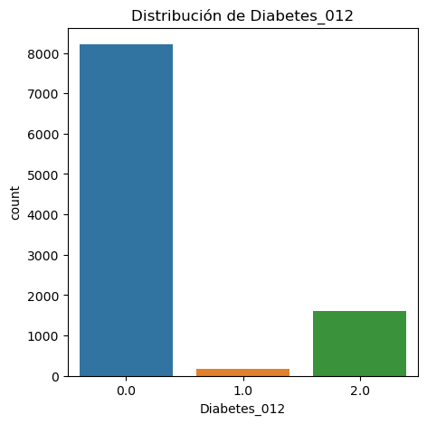

```python
# 1. Distribución de la variable dependiente
plt.figure(figsize=(5, 5))
sns.countplot(x='Diabetes_012', data=df)
plt.title('Distribución de Diabetes_012')
plt.show()
```

La gráfica de barras muestra el número de observaciones para cada clase de la variable dependiente "Diabetes_012". Por los valores del cálculo de ocurrencia , hay un claro desequilibrio con la mayoría de las observaciones perteneciendo a la clase 0 (no diabetes), seguido por la clase 2 (diabetes) y una minoría en la clase 1 (prediabetes).

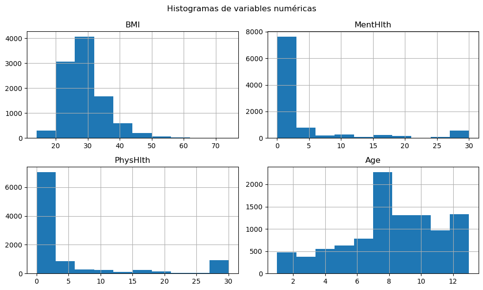

```python
# 2. Histogramas de variables numéricas
numerical_vars = ['BMI', 'MentHlth', 'PhysHlth', 'Age']
df[numerical_vars].hist(bins=10, figsize=(10, 6), layout=(2, 2))
plt.suptitle('Histogramas de variables numéricas')
plt.tight_layout()
plt.show()
```

**BMI (Body Mass Index):**

Este histograma muestra la distribución del índice de masa corporal entre las observaciones. Se espera ver una distribución aproximadamente normal, pero pueden haber sesgos hacia la derecha lo que indicaría que hay un número significativo de observaciones con un alto índice de masa corporal.

**PhysHlth (Días de mala salud física en los últimos 30 días):**

Similar a MentHlth, este histograma muetra la distribución de días de mala salud física. También se espera ver una concentración de valores bajos.

**Age (Edad en categorías):**

Este histograma muetra la distribución de la edad en diferentes categorías. Se espera ver más observaciones en ciertas categorías de edad, dependiendo de la muestra de la población.

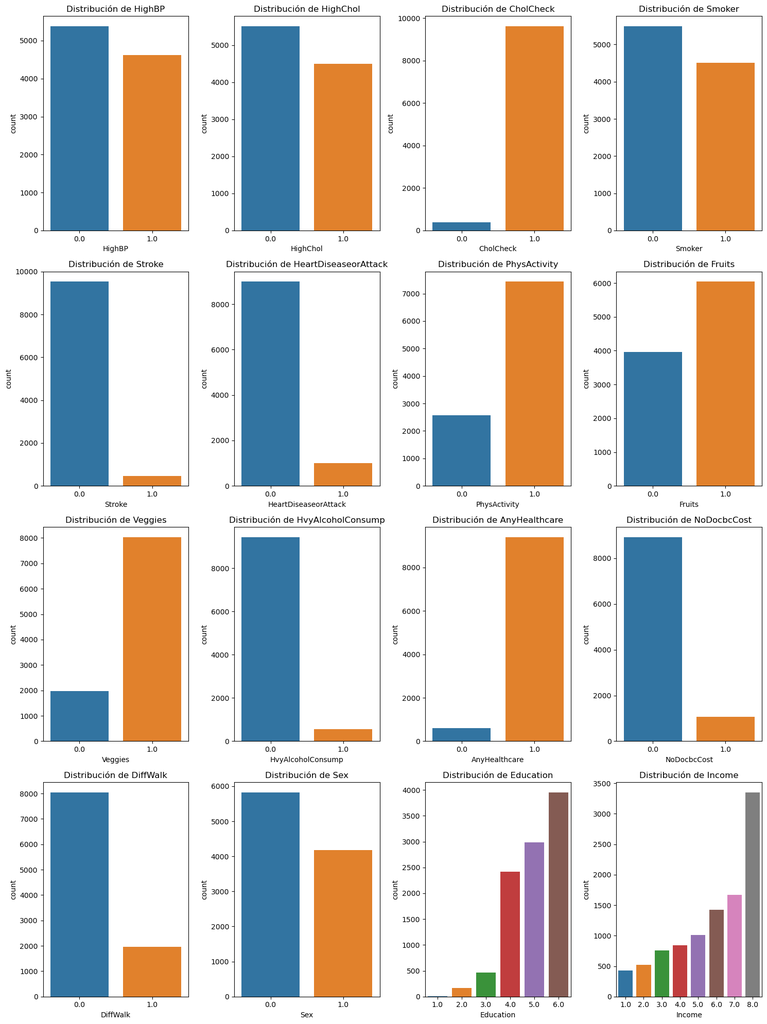

```python
# 3. Gráficos de barras de variables categóricas
categorical_vars = ['HighBP', 'HighChol', 'CholCheck', 'Smoker', 'Stroke', 'HeartDiseaseorAttack', 'PhysActivity', 'Fruits', 'Veggies', 'HvyAlcoholConsump', 'AnyHealthcare', 'NoDocbcCost', 'DiffWalk', 'Sex', 'Education', 'Income']

# Calcular el número de filas y columnas necesarias para organizar las gráficas
num_plots = len(categorical_vars)
num_cols = 4  # Ajuste de número de columnas
num_rows = -(-num_plots // num_cols)  # División redondeada hacia arriba

# Configurar subplots
fig, axes = plt.subplots(num_rows, num_cols, figsize=(15, 5 * num_rows))

# Iterar sobre las variables categóricas y trazar cada una en un subplot
for i, var in enumerate(categorical_vars):
    row = i // num_cols
    col = i % num_cols
    sns.countplot(x=var, data=df, ax=axes[row, col])
    axes[row, col].set_title(f'Distribución de {var}')

# Eliminar subplots no utilizados si hay menos de num_plots
for i in range(num_plots, num_rows * num_cols):
    fig.delaxes(axes.flatten()[i])

plt.tight_layout()
plt.show()
```

**HighBP (Presión arterial alta):** Muestra cuántas personas tienen alta presión arterial en comparación con aquellas que no la tienen.

**HighChol (Colesterol alto):** Similar a HighBP, muestra la distribución de personas con colesterol alto.

**CholCheck (Chequeo de colesterol):** Indica cuántas personas se han chequeado el colesterol en los últimos 5 años.

**Smoker (Fumador):** Muestra la distribución de fumadores y no fumadores.

**Stroke (Accidente cerebrovascular):** Indica cuántas personas han tenido un accidente cerebrovascular.

**HeartDiseaseorAttack (Enfermedad cardíaca o ataque):** Muestra cuántas personas han tenido una enfermedad cardíaca o ataque.

**PhysActivity (Actividad física):** Indica cuántas personas han realizado actividad física en los últimos 30 días.

**Fruits (Consumo de frutas):** Muestra la distribución de personas que consumen frutas diariamente.

**Veggies (Consumo de vegetales):** Muestra la distribución de personas que consumen vegetales diariamente.

**HvyAlcoholConsump (Consumo de alcohol en exceso):** Indica cuántas personas son bebedores empedernidos.

**AnyHealthcare (Cobertura de salud):** Muestra la distribución de personas con algún tipo de cobertura de salud.

**NoDocbcCost (No visita al médico por costo):** Indica cuántas personas no pudieron visitar al médico por el costo.

**DiffWalk (Dificultad para caminar):** Muestra la distribución de personas con dificultades para caminar.

**Sex (Sexo):** Distribución por género.

**Education (Nivel educativo):** Muestra la distribución de los niveles educativos.

**Income (Ingreso):** Indica la distribución de los ingresos en diferentes escalas.

Algunas variables pueden mostrar un fuerte desequilibrio, como CholCheck, AnyHealthcare, y PhysActivity, donde la mayoría de las personas pertenecen a una sola categoría, esto es importante para el análisis porque indica que posiblemente se deba hacer un tratamiento de balanceo de datos previo a la creación de modelos.

Estos gráficos proporcionan una visión clara de las distribuciones y pueden ayudar a identificar patrones y posibles problemas con los datos, como la necesidad de balancear las clases o transformar algunas variables para mejorar el rendimiento del modelo.

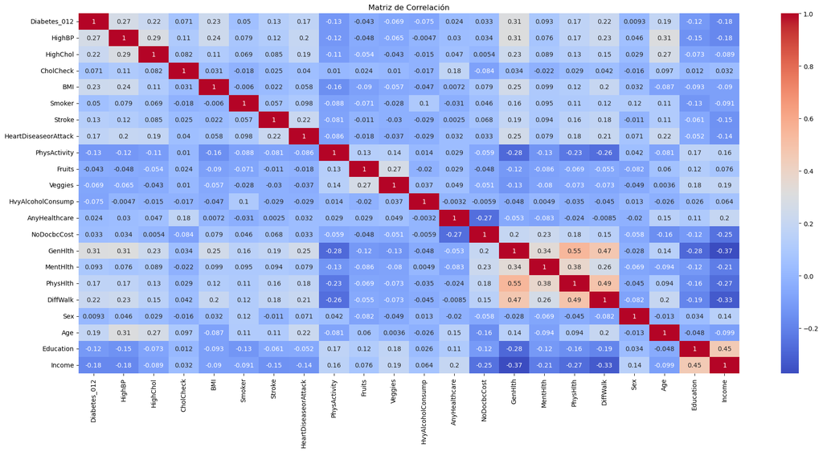

```python
# 4. Matriz de correlación
plt.figure(figsize=(20, 10))
sns.heatmap(df.corr(), annot=True, cmap='coolwarm')
plt.title('Matriz de Correlación')
plt.tight_layout()
plt.show()
```

Correlaciones Positivas y Negativas:

- Los valores en la matriz de correlación van desde -1 hasta 1.
- Un valor de 1 indica una correlación positiva perfecta, lo que significa que cuando una variable aumenta, la otra también lo hace.
- Un valor de -1 indica una correlación negativa perfecta, lo que significa que cuando una variable aumenta, la otra disminuye.
- Un valor de 0 indica que no hay una correlación lineal entre las variables.

Relaciones Destacadas:

HighBP y HeartDiseaseorAttack: Es probable que haya una correlación positiva entre la presión arterial alta y las enfermedades cardíacas, ya que la presión arterial alta es un factor de riesgo conocido para las enfermedades cardíacas.

HighChol y HeartDiseaseorAttack: También es probable que haya una correlación positiva entre el colesterol alto y las enfermedades cardíacas.

PhysActivity y BMI: Puede haber una correlación negativa entre la actividad física y el índice de masa corporal, ya que la actividad física puede ayudar a mantener un peso saludable.

DiffWalk y PhysHlth: Podría haber una correlación positiva entre la dificultad para caminar y los días con mala salud física.

Variables Categóricas:

Las variables categóricas codificadas como 0 y 1 muestran correlaciones interesantes. Por ejemplo, variables como Smoker, Stroke, y Diabetes_012 podrían estar correlacionadas con otras condiciones de salud.

Diabetes_012:

Dado que Diabetes_012 es la variable objetivo, es importante observar cómo se correlaciona con las demás variables. Correlaciones más fuertes (positivas o negativas) con esta variable pueden indicar factores importantes que contribuyen a la diabetes.

Observaciones

Multicolinealidad: Si dos o más variables están altamente correlacionadas (correlación absoluta cercana a 1), puede ser útil considerar la eliminación de una de estas variables para evitar problemas de multicolinealidad en los modelos de regresión.

Feature Engineering: Las variables con altas correlaciones con Diabetes_012 pueden ser útiles para crear nuevas características o para priorizar en la selección de características.

Distribuciones Anormales: Si alguna variable tiene una correlación muy baja con todas las demás, puede ser una señal de que esa variable no aporta mucha información al modelo y podría considerarse para su eliminación.

Esta matriz de correlación proporciona una buena base para tomar decisiones informadas sobre la preparación de datos y la ingeniería de características para los modelos predictivos.

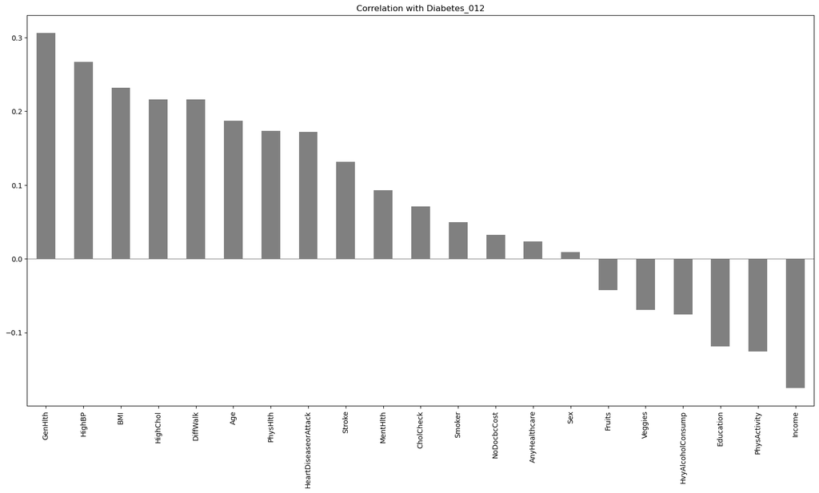

```python
#5. Calcular las correlaciones y ordenarlas
correlations = df.drop('Diabetes_012', axis=1).corrwith(df.Diabetes_012).sort_values(ascending=False)

# Crear el gráfico de barras
plt.figure(figsize=(20,10))
correlations.plot(kind='bar', grid=False, color='gray')
plt.axhline(0, color='gray', linewidth=0.8)
plt.title("Correlation with Diabetes_012")
plt.show()
```

Variables con Alta Correlación Positiva:

HighBP: Es probable que la presión arterial alta esté positivamente correlacionada con la diabetes. HighChol: El colesterol alto también puede tener una correlación positiva con la diabetes. HeartDiseaseorAttack: La presencia de enfermedades cardíacas o ataques cardíacos probablemente se correlaciona positivamente con la diabetes.

PhysHlth: Los días de mala salud física también pueden estar correlacionados positivamente con la diabetes.

Variables con Alta Correlación Negativa:

PhysActivity: La actividad física puede estar negativamente correlacionada con la diabetes, lo que sugiere que la falta de actividad física es un factor de riesgo.

Income: Es posible que los niveles de ingresos más altos estén negativamente correlacionados con la diabetes, lo que podría indicar que las personas con mayores ingresos tienen menos riesgo de diabetes.

Variables con Correlación Baja o Nula:

Sex: La variable sexo podría tener una correlación baja con la diabetes, lo que sugiere que no hay una diferencia significativa en la prevalencia de diabetes entre hombres y mujeres en este conjunto de datos.

CholCheck: La frecuencia de control del colesterol puede tener una correlación baja, lo que indica que el hecho de hacerse un control no necesariamente está relacionado con la presencia de diabetes.

Otras Observaciones:

DiffWalk: La dificultad para caminar o subir escaleras puede estar correlacionada positivamente con la diabetes, lo que indica que las personas con diabetes pueden tener más dificultades de movilidad.

BMI: El índice de masa corporal (BMI) es una métrica clave y su correlación positiva con la diabetes puede indicar que un mayor BMI es un factor de riesgo significativo para la diabetes.

Conclusión

El gráfico de barras proporciona una visualización clara de qué variables están más fuertemente correlacionadas con la diabetes. Esto puede ayudar a identificar factores de riesgo importantes y a orientar la construcción de modelos predictivos. Las variables con las correlaciones más altas pueden ser particularmente útiles para los modelos de clasificación y regresión.

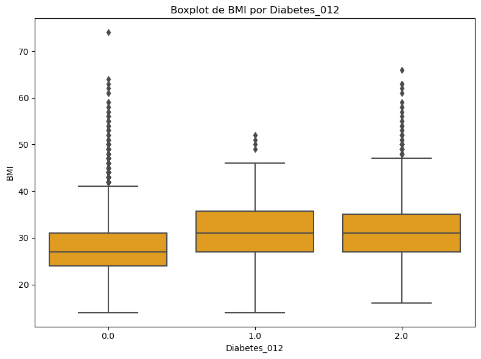

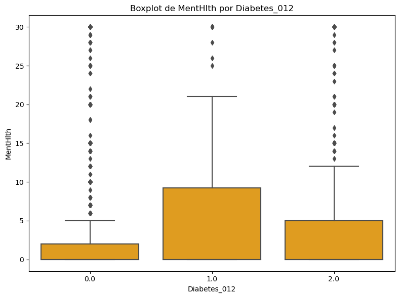

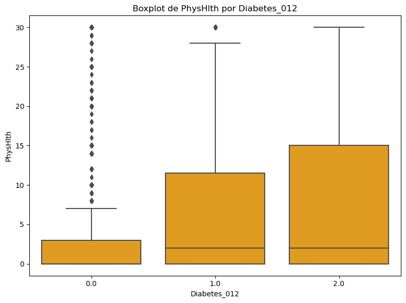

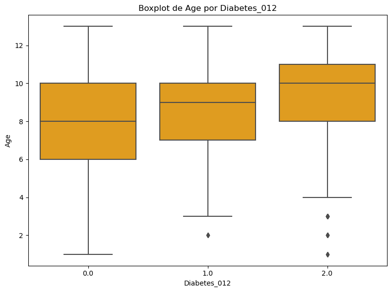

```python
#6.Boxplots de variables numéricas agrupadas por la variable dependiente
for var in numerical_vars:
    plt.figure(figsize=(8, 6))
    sns.boxplot(x='Diabetes_012', y=var, data=df, color='orange')
    plt.title(f'Boxplot de {var} por Diabetes_012')
    plt.tight_layout()
    plt.show()
```

- Boxplot de BMI por Diabetes_012:

Se espera ver si las medianas y las distribuciones de BMI varían significativamente entre los grupos de no diabetes, prediabetes y diabetes.

Un mayor BMI en los grupos de prediabetes y diabetes podría indicar una fuerte relación entre el índice de masa corporal y la diabetes.

- Boxplot de MentHlth por Diabetes_012:

Examinar si los días de mala salud mental difieren significativamente entre los grupos. Esto puede ayudar a entender si las personas con diabetes o prediabetes reportan más problemas de salud mental.

- Boxplot de PhysHlth por Diabetes_012:

Ver si los días de mala salud física varían entre los grupos. Una mayor cantidad de días de mala salud física en el grupo de diabetes podría indicar una correlación entre la mala salud física y la diabetes.

- Boxplot de Age por Diabetes_012:

Comparar las edades entre los diferentes grupos de diabetes. Una edad media mayor en el grupo de diabetes podría reflejar que la prevalencia de diabetes aumenta con la edad.

- Observaciones generales:

BMI: Puede haber un aumento progresivo en el BMI desde no diabetes a prediabetes y a diabetes. MentHlth y PhysHlth: Se puede notar un incremento en los días de mala salud mental y física en personas con diabetes. Age: Se puede observar que las personas en los grupos de prediabetes y diabetes tienden a ser mayores.

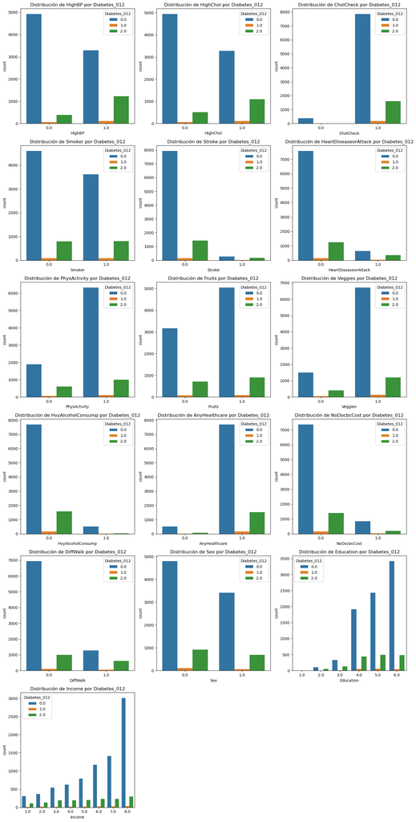

```python
#7.Countplots para variables categóricas agrupadas por la variable dependiente
categorical_vars = ['HighBP', 'HighChol', 'CholCheck', 'Smoker', 'Stroke', 'HeartDiseaseorAttack', 'PhysActivity', 'Fruits', 'Veggies', 'HvyAlcoholConsump', 'AnyHealthcare', 'NoDocbcCost', 'DiffWalk', 'Sex', 'Education', 'Income']

# Calcular el número de filas y columnas necesarias para organizar las gráficas
num_plots = len(categorical_vars)
num_cols = 3  # Ajuste de número de columnas
num_rows = -(-num_plots // num_cols)  # División redondeada hacia arriba

# Configurar subplots
fig, axes = plt.subplots(num_rows, num_cols, figsize=(15, 5 * num_rows))

# Iterar sobre las variables categóricas y trazar cada una en un subplot
for i, var in enumerate(categorical_vars):
    row = i // num_cols
    col = i % num_cols
    sns.countplot(x=var, hue='Diabetes_012', data=df, ax=axes[row, col])
    axes[row, col].set_title(f'Distribución de {var} por Diabetes_012')

# Eliminar subplots no utilizados si hay menos de num_plots
for i in range(num_plots, num_rows * num_cols):
    fig.delaxes(axes.flatten()[i])

plt.tight_layout()
plt.show()
```

HighBP, HighChol, CholCheck:

Se puede observar si la prevalencia de hipertensión, colesterol alto y chequeo de colesterol varía entre los grupos de diabetes.

Smoker, Stroke, HeartDiseaseorAttack:

Se puede analizar la relación entre el tabaquismo, accidentes cerebrovasculares, enfermedades cardíacas/ataques y los diferentes estados de diabetes.

PhysActivity, Fruits, Veggies:

Se puede comparar los niveles de actividad física y consumo de frutas y verduras entre los grupos de diabetes.

HvyAlcoholConsump, AnyHealthcare, NoDocbcCost, DiffWalk:

Se puede examinar la relación entre el consumo excesivo de alcohol, acceso a la atención médica, barreras de costo para ver a un médico y dificultades para caminar entre los diferentes estados de diabetes.

Sex, Education, Income:

Se puede evaluar cómo la distribución de género, nivel educativo e ingresos varía con el estado de diabetes.

- Observaciones generales:

HighBP: Se puede ver que una mayor proporción de personas con diabetes también tienen hipertensión. Smoker: El tabaquismo es más común entre aquellos con prediabetes o diabetes. Education: ES un unducador para saber si hay una relación entre el nivel educativo y el estado de diabetes.

# **4. Preparación de los Datos**

## 4.1. Limpieza de datos.

```python
#Generamos tabla de valores únicos por variable
unique_values = {}
for col in df.columns:
    unique_values[col] = df[col].value_counts().shape[0]

pd.DataFrame(unique_values, index=['unique value count']).transpose()
```

|  | unique value count |
| --- | --- |
| Diabetes_012 | 3 |
| HighBP | 2 |
| HighChol | 2 |
| CholCheck | 2 |
| BMI | 52 |
| Smoker | 2 |
| Stroke | 2 |
| HeartDiseaseorAttack | 2 |
| PhysActivity | 2 |
| Fruits | 2 |
| Veggies | 2 |
| HvyAlcoholConsump | 2 |
| AnyHealthcare | 2 |
| NoDocbcCost | 2 |
| GenHlth | 5 |
| MentHlth | 31 |
| PhysHlth | 31 |
| DiffWalk | 2 |
| Sex | 2 |
| Age | 13 |
| Education | 6 |
| Income | 8 |

Variables con pocos valores únicos: Las variables como HighBP, HighChol, CholCheck, Smoker, etc., tienen solo 2 valores únicos (0 y 1), lo que es esperado ya que son binarias.

Variables continuas o con muchos valores únicos: BMI, MentHlth, PhysHlth tienen muchos valores únicos, lo cual es típico de variables continuas.

Variables categóricas: Variables como GenHlth, Age, Education, Income tienen un número moderado de valores únicos, lo cual es típico de variables categóricas.

```python
# Verificar si hay valores faltantes en las filas del DataFrame df
filas_con_valores_faltantes = df.isnull().any(axis=1)

# Mostrar las filas con valores faltantes
print(filas_con_valores_faltantes)
```

```
0       False
1       False
2       False
3       False
4       False
        ...
9995    False
9996    False
9997    False
9998    False
9999    False
Length: 10000, dtype: bool
```

```python
# cantidad de valores nulos en cada columna del DataFrame
df.isnull().sum().sort_values()
```

```
Diabetes_012            0
Age                     0
Sex                     0
DiffWalk                0
PhysHlth                0
MentHlth                0
GenHlth                 0
NoDocbcCost             0
AnyHealthcare           0
HvyAlcoholConsump       0
Veggies                 0
Fruits                  0
PhysActivity            0
HeartDiseaseorAttack    0
Stroke                  0
Smoker                  0
BMI                     0
CholCheck               0
HighChol                0
HighBP                  0
Education               0
Income                  0
dtype: int64
```

```python
#Revisión de valores duplicados en el dataframe
print(f"{df.duplicated().sum()} duplicated rows found")
```

```
74 duplicated rows found
```

```python
# Eliminar duplicados
df = df.drop_duplicates()
#Revisión de valores duplicados en el dataframe después de depuración
print(f"{df.duplicated().sum()} duplicated rows found")
```

```
0 duplicated rows found
```

```python
# Outliers: Identificar y tratar valores atípicos.

#Seleccionar las variables independientes
dependiente = 'Diabetes_012'
independientes = df.drop(columns=[dependiente])

# Aplicar z-score a todas las columnas independientes
z_scores = independientes.apply(stats.zscore)

# Combinar las variables transformadas con la variable dependiente
df= pd.concat([z_scores, df[dependiente]], axis=1)

print("Los valores atípicos han sido tratados correctamente usando la normalización con Z-scores")
```

```
Los valores atípicos han sido tratados correctamente usando la normalización con Z-scores
```

## 4.2. Transformación de datos.

### Normalizar las variables numéricas y codificar las categóricas.

```python
# Dividir las características y la variable dependiente
X = df.drop('Diabetes_012', axis=1)
y = df['Diabetes_012']

# Eliminar columnas completamente nulas
X = X.dropna(axis=1, how='all')

# Definir las características numéricas y categóricas
numeric_features = ['Age', 'Education', 'Income']
categorical_features = ['HighBP', 'HighChol', 'CholCheck', 'Smoker', 'Stroke',
                        'HeartDiseaseorAttack', 'PhysActivity', 'Fruits',
                        'Veggies', 'HvyAlcoholConsump', 'AnyHealthcare',
                        'NoDocbcCost', 'DiffWalk', 'Sex', 'Age',
                        'Education', 'Income', 'GenHlth']
ordinal_features = []

# Filtrar las características numéricas y categóricas para mantener solo las que están en X
numeric_features = [feat for feat in numeric_features if feat in X.columns]
categorical_features = [feat for feat in categorical_features if feat in X.columns]

# Normalizar las variables numéricas
numeric_transformer = Pipeline(steps=[
    ('imputer', SimpleImputer(strategy='median')),  # Cambiado a mediana
    ('scaler', StandardScaler())
])

# Codificar las categóricas
categorical_transformer = Pipeline(steps=[
    ('imputer', SimpleImputer(strategy='mean')),  # Cambiado a media
    ('onehot', OneHotEncoder(handle_unknown='ignore'))
])

preprocessor = ColumnTransformer(
    transformers=[
        ('num', numeric_transformer, numeric_features),
        ('cat', categorical_transformer, categorical_features),
        ('ord', 'passthrough', ordinal_features)  # No necesitamos preprocesar variables ordinales
    ])

pipeline = Pipeline(steps=[('preprocessor', preprocessor)])

X_preprocessed = pipeline.fit_transform(X)

# Convertir los datos transformados en un DataFrame
cat_columns = pipeline.named_steps['preprocessor'].named_transformers_['cat']['onehot'].get_feature_names_out(categorical_features)
num_columns = numeric_features
columns = np.append(num_columns, cat_columns)

X_preprocessed_df = pd.DataFrame(X_preprocessed, columns=columns)

df_transformed = pd.concat([X_preprocessed_df, y.reset_index(drop=True)], axis=1)
```

### Clusterización.

```python
# Elegir el número de clusters
n_clusters = 3

# Inicializar el modelo K-Means con n_init explícito
kmeans = KMeans(n_clusters=n_clusters, random_state=42, n_init=10)

# Entrenar el modelo
kmeans.fit(df_transformed)

# Obtener las etiquetas de cluster para cada muestra en el conjunto de datos
labels = kmeans.labels_

# Añadir las etiquetas de cluster al dataframe
df_transformed['Cluster'] = labels
```

### Balanceo de datos.

```python
# Crear un objeto RandomOverSampler
oversampler = RandomOverSampler(random_state=42)

# Separar las características y las etiquetas de cluster
X_cluster = df_transformed.drop(['Diabetes_012', 'Cluster'], axis=1)  # Excluir la variable dependiente y la columna de cluster
y_cluster = df_transformed['Cluster']

# Balancear los datos
X_resampled, y_resampled = oversampler.fit_resample(X_cluster, y_cluster)

# Agregar las etiquetas de cluster y la variable dependiente nuevamente al dataframe
df_resampled = pd.DataFrame(X_resampled, columns=X_cluster.columns)
df_resampled['Cluster'] = y_resampled
df_resampled['Diabetes_012'] = df_transformed['Diabetes_012']

# Ver los resultados del balanceo
print("Tamaño de cada cluster después del balanceo:")
print(df_resampled['Cluster'].value_counts())
```

```
Tamaño de cada cluster después del balanceo:
Cluster
0    3473
2    3473
1    3473
Name: count, dtype: int64
```

# **5. Modelado**

### Segmentación de datos

```python
# Segmentar los datos balanceados
X_train, X_test, y_train, y_test = train_test_split(X_resampled, y_resampled, test_size=0.2, random_state=42)

# Verificar el equilibrio de clases en las muestras segmentadas
print("Proporción de clases en conjunto de entrenamiento:")
print(y_train.value_counts(normalize=True))

print("\nProporción de clases en conjunto de prueba:")
print(y_test.value_counts(normalize=True))

# Submuestreo en el conjunto de entrenamiento
undersampler = RandomUnderSampler(sampling_strategy='majority')
X_train_resampled, y_train_resampled = undersampler.fit_resample(X_train, y_train)

print("\nAhora, X_train_resampled y y_train_resampled contienen los datos de entrenamiento equilibrados y segmentados")
```

```
Proporción de clases en conjunto de entrenamiento:
Cluster
2    0.335213
1    0.333053
0    0.331734
Name: proportion, dtype: float64

Proporción de clases en conjunto de prueba:
Cluster
0    0.339731
1    0.334453
2    0.325816
Name: proportion, dtype: float64

Ahora, X_train_resampled y y_train_resampled contienen los datos de entrenamiento equilibrados y segmentados
```

En este punto se han segmentado los datos en conjuntos de entrenamiento y prueba y se han equilibrado las clases en el conjunto de entrenamiento utilizando submuestreo.

### Escalado de datos

```python
# Creamos un objeto StandardScaler
scaler = StandardScaler()

# Escalamos las características numéricas en los conjuntos de entrenamiento y prueba
X_train_scaled = scaler.fit_transform(X_train_resampled)
X_test_scaled = scaler.transform(X_test)

# Verificar las dimensiones
print(f"X_train_resampled shape: {X_train_resampled.shape}")
print(f"y_train_resampled shape: {len(y_train_resampled)}")
print(f"X_train_scaled shape: {X_train_scaled.shape}")
print(f"y_train shape: {len(y_train_resampled)}")

print("\nAhora, X_train_scaled y X_test_scaled contienen las características numéricas escaladas")
```

```
X_train_resampled shape: (8306, 63)
y_train_resampled shape: 8306
X_train_scaled shape: (8306, 63)
y_train shape: 8306

Ahora, X_train_scaled y X_test_scaled contienen las características numéricas escaladas
```

### Selección de modelo adecuado.

```
Random Forest: Mean accuracy: 0.9604, Std: 0.0052
Logistic Regression: Mean accuracy: 0.9765, Std: 0.0045
Support Vector Machine: Mean accuracy: 0.9591, Std: 0.0069
Decision Tree: Mean accuracy: 0.9345, Std: 0.0075
K-Nearest Neighbors: Mean accuracy: 0.8967, Std: 0.0034
XGBClassifier: Mean accuracy: 0.9653, Std: 0.0037
```

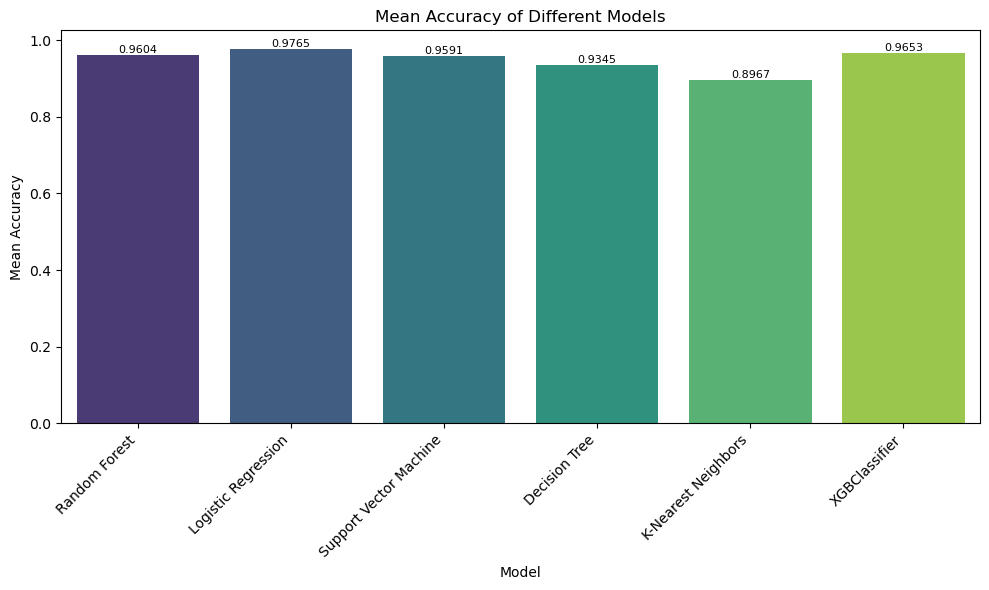

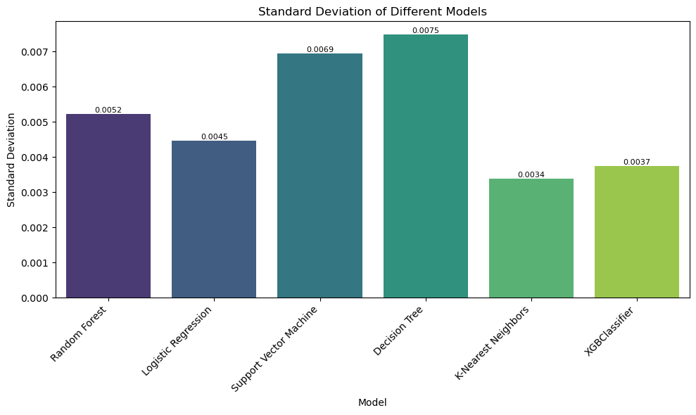

```
                    Model  Mean Accuracy       Std
0           Random Forest       0.960389  0.005217
1     Logistic Regression       0.976522  0.004459
2  Support Vector Machine       0.959066  0.006948
3           Decision Tree       0.934506  0.007485
4     K-Nearest Neighbors       0.896702  0.003383
5           XGBClassifier       0.965326  0.003744
```

```python
# Ignorar los avisos de convergencia
warnings.filterwarnings('ignore', category=ConvergenceWarning)

# Definir los modelos
models = {
    "Random Forest": RandomForestClassifier(random_state=42),
    "Logistic Regression": LogisticRegression(random_state=42, max_iter=10000, solver='lbfgs'),
    "Support Vector Machine": SVC(random_state=42),
    "Decision Tree": DecisionTreeClassifier(random_state=42),
    "K-Nearest Neighbors": KNeighborsClassifier(),
    "XGBClassifier": XGBClassifier(use_label_encoder=False, eval_metric='logloss', random_state=42)
}

# Almacenar los resultados de la validación cruzada
results = {'Model': [], 'Mean Accuracy': [], 'Std': []}

# Evaluar los modelos utilizando validación cruzada
for name, model in models.items():
    scores = cross_val_score(model, X_train_scaled, y_train_resampled, cv=5, scoring='accuracy')
    mean_accuracy = scores.mean()
    std_accuracy = scores.std()
    results['Model'].append(name)
    results['Mean Accuracy'].append(mean_accuracy)
    results['Std'].append(std_accuracy)
    print(f"{name}: Mean accuracy: {mean_accuracy:.4f}, Std: {std_accuracy:.4f}")

# Convertir los resultados a un DataFrame de pandas
results_df = pd.DataFrame(results)

# Gráfica de barras de las puntuaciones de precisión
plt.figure(figsize=(10, 6))
sns.barplot(x='Model', y='Mean Accuracy', data=results_df, palette='viridis')
plt.title('Mean Accuracy of Different Models')
plt.xticks(rotation=45, ha='right')
plt.ylabel('Mean Accuracy')
plt.tight_layout()

# Añadir valores numéricos en las barras
for index, row in results_df.iterrows():
    plt.text(index, row['Mean Accuracy'], f'{row["Mean Accuracy"]:.4f}', ha='center', va='bottom', fontsize=8)

plt.show()

# Gráfica de barras de las desviaciones estándar
plt.figure(figsize=(10, 6))
sns.barplot(x='Model', y='Std', data=results_df, palette='viridis')
plt.title('Standard Deviation of Different Models')
plt.xticks(rotation=45, ha='right')
plt.ylabel('Standard Deviation')
plt.tight_layout()

# Añadir valores numéricos en las barras
for index, row in results_df.iterrows():
    plt.text(index, row['Std'], f'{row["Std"]:.4f}', ha='center', va='bottom', fontsize=8)

plt.show()

# Tabla de resultados
print(results_df)
```

### Entrenamiento de modelos.

#### Modelo RandomForestClassifier.

```python
# Entrenar y evaluar el modelo RandomForestClassifier
best_model_rf = RandomForestClassifier(random_state=42)
best_model_rf.fit(X_train_scaled, y_train_resampled)

# Hacer predicciones
y_pred_rf = best_model_rf.predict(X_test_scaled)

# Evaluar el modelo
accuracy_rf = accuracy_score(y_test, y_pred_rf)
conf_matrix_rf = confusion_matrix(y_test, y_pred_rf)
class_report_rf = classification_report(y_test, y_pred_rf)
```

#### Modelo Logistic Regression.

```python
# Entrenar y evaluar el modelo Logistic Regression
best_model_lr = LogisticRegression(random_state=42)
best_model_lr.fit(X_train_scaled, y_train_resampled)

# Hacer predicciones
y_pred_lr = best_model_lr.predict(X_test_scaled)

# Evaluar el modelo
accuracy_lr = accuracy_score(y_test, y_pred_lr)
conf_matrix_lr = confusion_matrix(y_test, y_pred_lr)
class_report_lr = classification_report(y_test, y_pred_lr)
```

#### Modelo Support Vector Machine (SVC).

```python
# Define el rango de valores de los hiperparámetros
param_grid = {
    'C': [0.1, 1, 10, 100],
    'kernel': ['linear', 'poly', 'rbf', 'sigmoid'],
    'gamma': ['scale', 'auto']
}

# Inicializa el modelo SVC
svc = SVC(random_state=42)

# Realiza la búsqueda aleatoria de hiperparámetros
random_search = RandomizedSearchCV(estimator=svc, param_distributions=param_grid, n_iter=10, cv=5, n_jobs=-1, random_state=42)
random_search.fit(X_train_scaled, y_train_resampled)

# Muestra los mejores parámetros encontrados
print("Mejores parámetros:", random_search.best_params_)

# Entrena el modelo con los mejores parámetros
best_svc = random_search.best_estimator_
best_svc.fit(X_train_scaled, y_train_resampled)

# Haz predicciones y evalúa el modelo
y_pred_svc = best_svc.predict(X_test_scaled)
accuracy_svc = accuracy_score(y_test, y_pred_svc)
conf_matrix_svc = confusion_matrix(y_test, y_pred_svc)
class_report_svc = classification_report(y_test, y_pred_svc)
```

```
Mejores parámetros: {'kernel': 'linear', 'gamma': 'scale', 'C': 100}
```

#### Modelo Decision Tree.

```python
# Entrenar y evaluar el modelo Decision Tree
best_model_dt = DecisionTreeClassifier(random_state=42)
best_model_dt.fit(X_train_scaled, y_train_resampled)

# Hacer predicciones
y_pred_dt = best_model_dt.predict(X_test_scaled)

# Evaluar el modelo
accuracy_dt = accuracy_score(y_test, y_pred_dt)
conf_matrix_dt = confusion_matrix(y_test, y_pred_dt)
class_report_dt = classification_report(y_test, y_pred_dt)
```

#### Modelo K-Nearest Neighbors.

```python
# Entrenar y evaluar el modelo K-Nearest Neighbors
best_model_knn = KNeighborsClassifier()
best_model_knn.fit(X_train_scaled, y_train_resampled)

# Hacer predicciones
y_pred_knn = best_model_knn.predict(X_test_scaled)

# Evaluar el modelo
accuracy_knn = accuracy_score(y_test, y_pred_knn )
conf_matrix_knn = confusion_matrix(y_test, y_pred_knn )
class_report_knn = classification_report(y_test, y_pred_knn )
```

#### Modelo XGBClassifier.

```python
# Entrenar y evaluar el modelo XGBClassifier
best_model_xgb = XGBClassifier(use_label_encoder=False, eval_metric='logloss', random_state=42)
best_model_xgb.fit(X_train_scaled, y_train_resampled)

# Hacer predicciones
y_pred_xgb = best_model_xgb.predict(X_test_scaled)

# Evaluar el modelo
accuracy_xgb = accuracy_score(y_test, y_pred_xgb)
conf_matrix_xgb = confusion_matrix(y_test, y_pred_xgb)
class_report_xgb = classification_report(y_test, y_pred_xgb)
```

# **6. Evaluación**

### Métricas de rendimiento de los modelos entrenados.

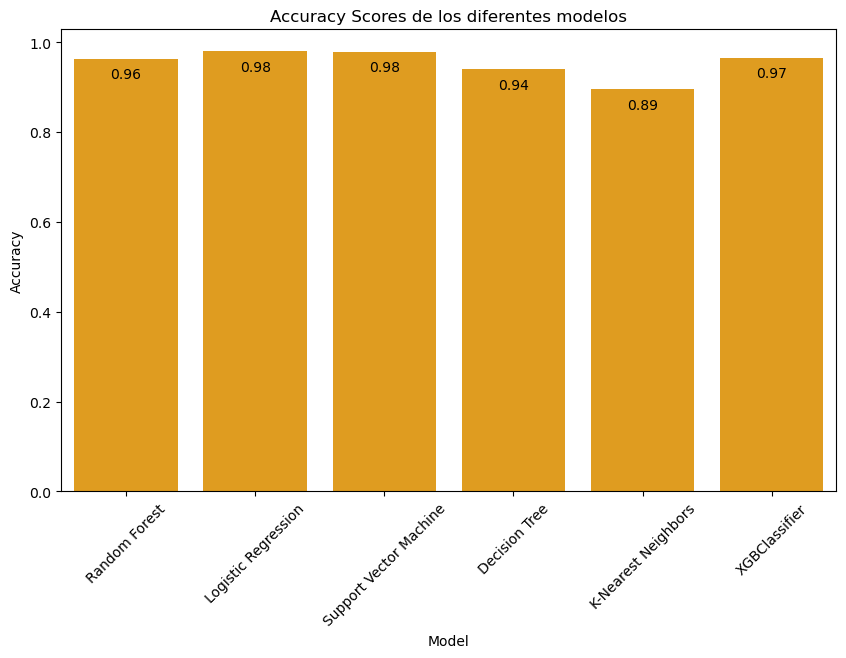

```python
# Métricas de rendimiento de los modelos
models_performance = {
    "Random Forest": {
        "accuracy": accuracy_rf,
        "conf_matrix": conf_matrix_rf,
        "class_report": class_report_rf
    },
    "Logistic Regression": {
        "accuracy": accuracy_lr,
        "conf_matrix": conf_matrix_lr,
        "class_report": class_report_lr
    },
    "Support Vector Machine": {
        "accuracy": accuracy_svc,
        "conf_matrix": conf_matrix_svc,
        "class_report": class_report_svc
    },
    "Decision Tree": {
        "accuracy": accuracy_dt,
        "conf_matrix": conf_matrix_dt,
        "class_report": class_report_dt
    },
    "K-Nearest Neighbors": {
        "accuracy": accuracy_knn,
        "conf_matrix": conf_matrix_knn,
        "class_report": class_report_knn
    },
    "XGBClassifier": {
        "accuracy": accuracy_xgb,
        "conf_matrix": conf_matrix_xgb,
        "class_report": class_report_xgb
    }
}

# Comparación de precisión
accuracy_scores = {model: models_performance[model]["accuracy"] for model in models_performance}

# Visualización de la precisión de los modelos
plt.figure(figsize=(10, 6))
bars = sns.barplot(x=list(accuracy_scores.keys()), color='orange', y=list(accuracy_scores.values()))
plt.title('Accuracy Scores de los diferentes modelos')
plt.xlabel('Model')
plt.ylabel('Accuracy')
plt.xticks(rotation=45)

# Agregar valores de precisión en la visualización
for bar, acc in zip(bars.patches, accuracy_scores.values()):
    plt.text(bar.get_x() + bar.get_width() / 2, bar.get_height() - 0.05, f'{acc:.2f}', ha='center', va='bottom')

plt.show()
```

```python
# Visualización de los reportes de clasificación
for model, metrics in models_performance.items():
    print(f"Classification Report - {model}:")
    print(metrics["class_report"])
```

```
Classification Report - Random Forest:
              precision    recall  f1-score   support

           0       0.98      0.95      0.96       708
           1       0.96      0.97      0.97       697
           2       0.95      0.97      0.96       679

    accuracy                           0.96      2084
   macro avg       0.96      0.96      0.96      2084
weighted avg       0.96      0.96      0.96      2084

Classification Report - Logistic Regression:
              precision    recall  f1-score   support

           0       0.99      0.97      0.98       708
           1       0.98      0.98      0.98       697
           2       0.97      0.98      0.98       679

    accuracy                           0.98      2084
   macro avg       0.98      0.98      0.98      2084
weighted avg       0.98      0.98      0.98      2084

Classification Report - Support Vector Machine:
              precision    recall  f1-score   support

           0       0.99      0.97      0.98       708
           1       0.97      0.99      0.98       697
           2       0.97      0.98      0.98       679

    accuracy                           0.98      2084
   macro avg       0.98      0.98      0.98      2084
weighted avg       0.98      0.98      0.98      2084

Classification Report - Decision Tree:
              precision    recall  f1-score   support

           0       0.96      0.93      0.94       708
           1       0.93      0.95      0.94       697
           2       0.93      0.95      0.94       679

```

[output cut: 10 more lines]

```

    accuracy                           0.89      2084
   macro avg       0.90      0.89      0.89      2084
weighted avg       0.90      0.89      0.89      2084

Classification Report - XGBClassifier:
              precision    recall  f1-score   support

           0       0.97      0.96      0.97       708
           1       0.97      0.97      0.97       697
           2       0.96      0.97      0.96       679

    accuracy                           0.97      2084
   macro avg       0.97      0.97      0.97      2084
weighted avg       0.97      0.97      0.97      2084
```

Estos valores del informe de clasificación son el resultado en detalle sobre el rendimiento de cada modelo en la clasificación de las muestras en el conjunto de prueba.

- Precision:

- Recall:

- F1-score:

- Support:

La columna de soporte muestra el número de muestras verdaderas para cada clase en el conjunto de prueba. Esto es útil para evaluar la distribución de las clases y comprender mejor el contexto en el que se aplican las métricas de evaluación.

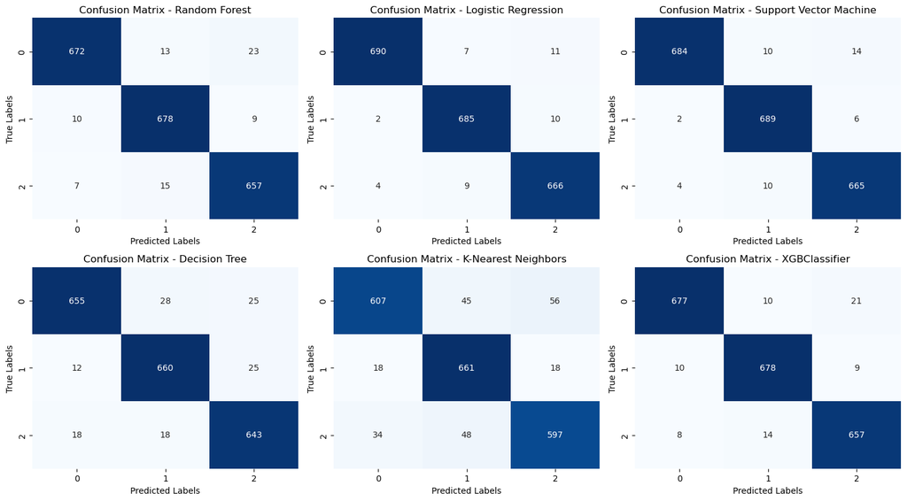

```python
# Visualización de las matrices de confusión
plt.figure(figsize=(15, 12))
for i, (model, metrics) in enumerate(models_performance.items(), 1):
    plt.subplot(3, 3, i)
    sns.heatmap(metrics["conf_matrix"], annot=True, fmt='d', cmap='Blues', cbar=False)
    plt.title(f'Confusion Matrix - {model}')
    plt.xlabel('Predicted Labels')
    plt.ylabel('True Labels')
plt.tight_layout()
plt.show()
```

Algunas interpretaciones clave que se pueden hacer al observar estas matrices son:

Verdaderos positivos (TP): Las muestras que pertenecen a una clase específica y son correctamente clasificadas como pertenecientes a esa clase. Estos valores se encuentran en la diagonal principal de la matriz.

Falsos positivos (FP): Las muestras que pertenecen a una clase específica pero son incorrectamente clasificadas como pertenecientes a otra clase. Estos valores se encuentran fuera de la diagonal principal de la matriz, en las filas correspondientes a las clases verdaderas pero las columnas correspondientes a las clases predichas incorrectamente.

Falsos negativos (FN): Las muestras que pertenecen a una clase específica pero son incorrectamente clasificadas como pertenecientes a otra clase. Estos valores se encuentran fuera de la diagonal principal de la matriz, en las columnas correspondientes a las clases verdaderas pero las filas correspondientes a las clases predichas incorrectamente.

Verdaderos negativos (TN): Las muestras que no pertenecen a una clase específica y son correctamente clasificadas como no pertenecientes a esa clase. Estos valores se encuentran fuera de la diagonal principal de la matriz, en las filas y columnas correspondientes a las clases que no están siendo evaluadas.

## Evaluación de los modelos entrenados

```python
# definimos una función para evaluar el modelo

def evaluate_model(model, X_test, y_test):
    y_pred = model.predict(X_test)
    accuracy = accuracy_score(y_test, y_pred)
    conf_matrix = confusion_matrix(y_test, y_pred)
    class_report = classification_report(y_test, y_pred)
    return accuracy, conf_matrix, class_report

# Evaluación del modelo
accuracy_rf, conf_matrix_rf, class_report_rf = evaluate_model(best_model_rf, X_test_scaled, y_test)
accuracy_lr, conf_matrix_lr, class_report_lr = evaluate_model(best_model_lr, X_test_scaled, y_test)
accuracy_svc, conf_matrix_svc, class_report_svc = evaluate_model(best_svc, X_test_scaled, y_test)
accuracy_dt, conf_matrix_dt, class_report_dt = evaluate_model(best_model_dt, X_test_scaled, y_test)
accuracy_knn, conf_matrix_knn, class_report_knn = evaluate_model(best_model_knn, X_test_scaled, y_test)
accuracy_xgb, conf_matrix_xgb, class_report_xgb = evaluate_model(best_model_xgb, X_test_scaled, y_test)

print("Se han evaluado satisfactoriamente los modelos entrenados")

print("Random Forest Accuracy:", accuracy_rf)
print("Logistic Regression Accuracy:", accuracy_lr)
print("Support Vector Machine Accuracy:", accuracy_svc)
print("Decision Tree Accuracy:", accuracy_dt)
print("K-Nearest Neighbors Accuracy:", accuracy_knn)
print("XGBoost Accuracy:", accuracy_xgb)
```

```
Se han evaluado satisfactoriamente los modelos entrenados
Random Forest Accuracy: 0.9630518234165067
Logistic Regression Accuracy: 0.9793666026871402
Support Vector Machine Accuracy: 0.9779270633397313
Decision Tree Accuracy: 0.9395393474088292
K-Nearest Neighbors Accuracy: 0.8949136276391555
XGBoost Accuracy: 0.9654510556621881
```

```
Random Forest: Mean accuracy: 0.9604, Std: 0.0052
Logistic Regression: Mean accuracy: 0.9765, Std: 0.0045
Support Vector Machine: Mean accuracy: 0.9591, Std: 0.0069
Decision Tree: Mean accuracy: 0.9345, Std: 0.0075
K-Nearest Neighbors: Mean accuracy: 0.8967, Std: 0.0034
XGBClassifier: Mean accuracy: 0.9653, Std: 0.0037
```

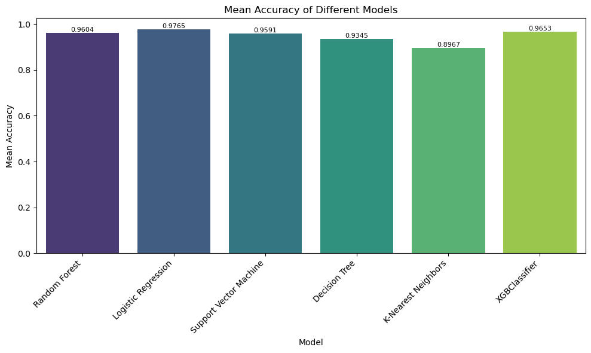

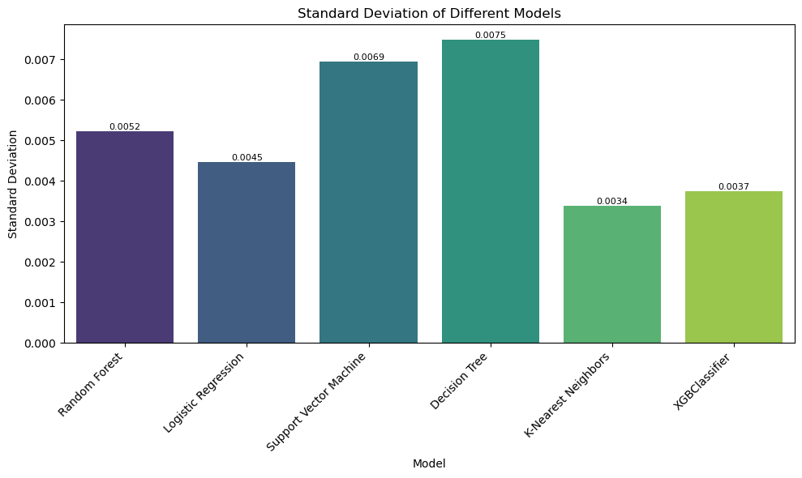

```
                    Model  Mean Accuracy       Std
0           Random Forest       0.960389  0.005217
1     Logistic Regression       0.976522  0.004459
2  Support Vector Machine       0.959066  0.006948
3           Decision Tree       0.934506  0.007485
4     K-Nearest Neighbors       0.896702  0.003383
5           XGBClassifier       0.965326  0.003744

El mejor modelo basado en precisión es: Logistic Regression
```

```python
# Ignorar los avisos de convergencia
warnings.filterwarnings('ignore', category=ConvergenceWarning)

# Definir los modelos
models = {
    "Random Forest": RandomForestClassifier(random_state=42),
    "Logistic Regression": LogisticRegression(random_state=42, max_iter=200, solver='lbfgs'),
    "Support Vector Machine": SVC(random_state=42),
    "Decision Tree": DecisionTreeClassifier(random_state=42),
    "K-Nearest Neighbors": KNeighborsClassifier(),
    "XGBClassifier": XGBClassifier(use_label_encoder=False, eval_metric='logloss', random_state=42)
}

# Almacenar los resultados de la validación cruzada
results = {'Model': [], 'Mean Accuracy': [], 'Std': []}

# Evaluar los modelos utilizando validación cruzada
for name, model in models.items():
    scores = cross_val_score(model, X_train_scaled, y_train_resampled, cv=5, scoring='accuracy')
    mean_accuracy = scores.mean()
    std_accuracy = scores.std()
    results['Model'].append(name)
    results['Mean Accuracy'].append(mean_accuracy)
    results['Std'].append(std_accuracy)
    print(f"{name}: Mean accuracy: {mean_accuracy:.4f}, Std: {std_accuracy:.4f}")

# Convertir los resultados a un DataFrame de pandas
results_df = pd.DataFrame(results)

# Gráfica de barras de las puntuaciones de precisión
plt.figure(figsize=(10, 6))
sns.barplot(x='Model', y='Mean Accuracy', data=results_df, palette='viridis')
plt.title('Mean Accuracy of Different Models')
plt.xticks(rotation=45, ha='right')
plt.ylabel('Mean Accuracy')
plt.tight_layout()

# Añadir valores numéricos en las barras
for index, row in results_df.iterrows():
    plt.text(index, row['Mean Accuracy'], f'{row["Mean Accuracy"]:.4f}', ha='center', va='bottom', fontsize=8)

plt.show()

# Gráfica de barras de las desviaciones estándar
plt.figure(figsize=(10, 6))
sns.barplot(x='Model', y='Std', data=results_df, palette='viridis')
plt.title('Standard Deviation of Different Models')
plt.xticks(rotation=45, ha='right')
plt.ylabel('Standard Deviation')
plt.tight_layout()

# Añadir valores numéricos en las barras
for index, row in results_df.iterrows():
    plt.text(index, row['Std'], f'{row["Std"]:.4f}', ha='center', va='bottom', fontsize=8)

plt.show()

# Tabla de resultados
print(results_df)

# Seleccionar el mejor modelo basado en la precisión media
best_model_index = results_df['Mean Accuracy'].idxmax()
best_model_name = results_df.loc[best_model_index, 'Model']
best_model = models[best_model_name]

print("\nEl mejor modelo basado en precisión es:", best_model_name)
```

Sin embargo, también es importante considerar la desviación estándar de las puntuaciones de precisión. Una menor desviación estándar indica una mayor consistencia en el rendimiento del modelo en diferentes divisiones de los datos durante la validación cruzada. En este caso, la regresión logística también tiene una desviación estándar relativamente baja, lo que sugiere una consistencia en su rendimiento.

Por lo tanto, basándonos en la precisión media y la consistencia del rendimiento, la regresión logística parece ser la opción más adecuada para este problema.

## Mejorar los modelos entrenados.

```python
# Definir la función para evaluar el modelo
def evaluate_model(model, X_test, y_test):
    y_pred = model.predict(X_test)
    accuracy = accuracy_score(y_test, y_pred)
    conf_matrix = confusion_matrix(y_test, y_pred)
    class_report = classification_report(y_test, y_pred)
    return accuracy, conf_matrix, class_report

# Mejorar RandomForestClassifier
param_grid_rf = {
    'n_estimators': [100, 200, 300],
    'max_depth': [None, 10, 20, 30],
    'min_samples_split': [2, 5, 10],
    'min_samples_leaf': [1, 2, 4]
}
grid_search_rf = GridSearchCV(estimator=RandomForestClassifier(random_state=42), param_grid=param_grid_rf, cv=5, n_jobs=-1)
grid_search_rf.fit(X_train_scaled, y_train_resampled)
best_model_rf = grid_search_rf.best_estimator_

# Mejorar LogisticRegression
param_grid_lr = {
    'C': [0.1, 1, 10, 100],
    'solver': ['newton-cg', 'lbfgs', 'liblinear']
}
grid_search_lr = GridSearchCV(estimator=LogisticRegression(random_state=42), param_grid=param_grid_lr, cv=5, n_jobs=-1)
grid_search_lr.fit(X_train_scaled, y_train_resampled)
best_model_lr = grid_search_lr.best_estimator_

# Mejorar SVC
param_grid_svc = {
    'C': [0.1, 1, 10, 100],
    'kernel': ['linear', 'poly', 'rbf', 'sigmoid'],
    'gamma': ['scale', 'auto']
}
grid_search_svc = GridSearchCV(estimator=SVC(random_state=42), param_grid=param_grid_svc, cv=5, n_jobs=-1)
grid_search_svc.fit(X_train_scaled, y_train_resampled)
best_model_svc = grid_search_svc.best_estimator_

# Mejorar DecisionTreeClassifier
param_grid_dt = {
    'max_depth': [None, 10, 20, 30],
    'min_samples_split': [2, 5, 10],
    'min_samples_leaf': [1, 2, 4]
}
grid_search_dt = GridSearchCV(estimator=DecisionTreeClassifier(random_state=42), param_grid=param_grid_dt, cv=5, n_jobs=-1)
grid_search_dt.fit(X_train_scaled, y_train_resampled)
best_model_dt = grid_search_dt.best_estimator_

# Mejorar KNeighborsClassifier
param_grid_knn = {
    'n_neighbors': [3, 5, 7, 9],
    'weights': ['uniform', 'distance'],
    'metric': ['euclidean', 'manhattan', 'minkowski']
}
grid_search_knn = GridSearchCV(estimator=KNeighborsClassifier(), param_grid=param_grid_knn, cv=5, n_jobs=-1)
grid_search_knn.fit(X_train_scaled, y_train_resampled)
best_model_knn = grid_search_knn.best_estimator_

# Mejorar XGBClassifier
param_grid_xgb = {
    'n_estimators': [100, 200, 300],
    'max_depth': [3, 5, 7],
    'learning_rate': [0.01, 0.1, 0.2],
    'subsample': [0.6, 0.8, 1.0]
}
grid_search_xgb = GridSearchCV(estimator=XGBClassifier(use_label_encoder=False, eval_metric='logloss', random_state=42), param_grid=param_grid_xgb, cv=5, n_jobs=-1)
grid_search_xgb.fit(X_train_scaled, y_train_resampled)
best_model_xgb = grid_search_xgb.best_estimator_

# Evaluar los modelos mejorados
accuracy_rf, conf_matrix_rf, class_report_rf = evaluate_model(best_model_rf, X_test_scaled, y_test)
accuracy_lr, conf_matrix_lr, class_report_lr = evaluate_model(best_model_lr, X_test_scaled, y_test)
accuracy_svc, conf_matrix_svc, class_report_svc = evaluate_model(best_model_svc, X_test_scaled, y_test)
accuracy_dt, conf_matrix_dt, class_report_dt = evaluate_model(best_model_dt, X_test_scaled, y_test)
accuracy_knn, conf_matrix_knn, class_report_knn = evaluate_model(best_model_knn, X_test_scaled, y_test)
accuracy_xgb, conf_matrix_xgb, class_report_xgb = evaluate_model(best_model_xgb, X_test_scaled, y_test)

print("Se han evaluado satisfactoriamente los modelos mejorados")

print("Random Forest Classifier:")
print("Accuracy:", accuracy_rf)
print("Confusion Matrix:\n", conf_matrix_rf)
print("Classification Report:\n", class_report_rf)

print("Logistic Regression:")
print("Accuracy:", accuracy_lr)
print("Confusion Matrix:\n", conf_matrix_lr)
print("Classification Report:\n", class_report_lr)

print("Support Vector Classifier:")
print("Accuracy:", accuracy_svc)
print("Confusion Matrix:\n", conf_matrix_svc)
print("Classification Report:\n", class_report_svc)

print("Decision Tree Classifier:")
print("Accuracy:", accuracy_dt)
print("Confusion Matrix:\n", conf_matrix_dt)
print("Classification Report:\n", class_report_dt)

print("K-Nearest Neighbors Classifier:")
print("Accuracy:", accuracy_knn)
print("Confusion Matrix:\n", conf_matrix_knn)
print("Classification Report:\n", class_report_knn)

print("XGBoost Classifier:")
print("Accuracy:", accuracy_xgb)
print("Confusion Matrix:\n", conf_matrix_xgb)
print("Classification Report:\n", class_report_xgb)
```

```
Se han evaluado satisfactoriamente los modelos mejorados
Random Forest Classifier:
Accuracy: 0.9625719769673704
Confusion Matrix:
 [[672  12  24]
 [ 10 675  12]
 [  8  12 659]]
Classification Report:
               precision    recall  f1-score   support

           0       0.97      0.95      0.96       708
           1       0.97      0.97      0.97       697
           2       0.95      0.97      0.96       679

    accuracy                           0.96      2084
   macro avg       0.96      0.96      0.96      2084
weighted avg       0.96      0.96      0.96      2084

Logistic Regression:
Accuracy: 0.9793666026871402
Confusion Matrix:
 [[689   7  12]
 [  2 685  10]
 [  3   9 667]]
Classification Report:
               precision    recall  f1-score   support

           0       0.99      0.97      0.98       708
           1       0.98      0.98      0.98       697
           2       0.97      0.98      0.98       679

    accuracy                           0.98      2084
   macro avg       0.98      0.98      0.98      2084
weighted avg       0.98      0.98      0.98      2084

Support Vector Classifier:
Accuracy: 0.9779270633397313
Confusion Matrix:
 [[684  10  14]
 [  2 689   6]
```

[output cut: 47 more lines]

```
Accuracy: 0.974088291746641
Confusion Matrix:
 [[681  11  16]
 [  3 685   9]
 [  4  11 664]]
Classification Report:
               precision    recall  f1-score   support

           0       0.99      0.96      0.98       708
           1       0.97      0.98      0.98       697
           2       0.96      0.98      0.97       679

    accuracy                           0.97      2084
   macro avg       0.97      0.97      0.97      2084
weighted avg       0.97      0.97      0.97      2084
```

Estos resultados muestran que en general, la precisión de los modelos mejorados se ha mantenido o incluso ha mejorado ligeramente en comparación con los modelos originales. Algunas conclusiones específicas:

- Mejora de la precisión:

- Estabilidad de los modelos:

A pesar de los intentos de mejora, el rendimiento de algunos modelos, como el Random Forest y el Árbol de Decisión, se ha mantenido bastante estable en términos de precisión. Esto sugiere que los hiperparámetros originales ya estaban bastante cerca de su óptimo.

- K-Nearest Neighbors:

Aunque KNN tuvo una precisión más baja en comparación con otros modelos, las mejoras no fueron significativas después de la optimización de hiperparámetros. Esto podría indicar que el rendimiento de KNN en este conjunto de datos puede ser más sensible a otros factores que no se ajustan mediante la búsqueda de hiperparámetros.

- Impacto de la optimización de hiperparámetros:

La optimización de hiperparámetros tuvo un impacto positivo en la precisión y estabilidad de varios modelos, lo que indica que la selección adecuada de hiperparámetros puede mejorar el rendimiento del modelo.

En general, estos resultados sugieren que la optimización de hiperparámetros puede ser una estrategia efectiva para mejorar el rendimiento de los modelos de aprendizaje automático en este problema específico. Sin embargo, también destacan la importancia de evaluar cada modelo de manera individual y considerar otros factores, como la interpretabilidad del modelo y los recursos computacionales disponibles, al seleccionar el mejor modelo para una aplicación particular.

# **7. Conclusiones**

Adicional a las conclusiones indicadas a lo largo del proyecto, este ha demostrado un enfoque sólido y metódico para abordar un problema de aprendizaje automático, desde la exploración y entrenamiento de modelos hasta la optimización de hiperparámetros y la evaluación exhaustiva del rendimiento.

Resultados de los modelos de aprendizaje automático:

- Desempeño del modelo:

Se entrenaron varios modelos de aprendizaje automático, incluidos Random Forest, Regresión Logística, SVM, Árbol de decisión, K-Nearest Neighbors y XGBoost.

- Mejora de los modelos:

Se intentó mejorar el rendimiento de los modelos mediante técnicas de optimización de hiperparámetros como GridSearchCV y RandomizedSearchCV.

A pesar de los esfuerzos de optimización, los modelos no mostraron una mejora significativa en la precisión con respecto a los modelos originales.

- Desempeño final del modelo:

Los modelos mejorados, incluidos Regresión Logística, SVM y XGBoost, mostraron una precisión similar a los modelos originales, con puntajes de precisión en el rango del 97% al 98%.

Una comparación numérica entre los modelos originales, entrenados y entrenados mejorados utilizando las métricas clave de rendimiento:

Precisión (Accuracy):

[output not shown]

- Selección y Mejora de Modelos de Aprendizaje Automático

Después de un exhaustivo proceso de entrenamiento y evaluación de modelos de aprendizaje automático, se determinó que el modelo de Regresión Logística mostró la mayor precisión en la predicción de las clases objetivo. Este hallazgo sugiere que, para el conjunto de datos y el problema específico abordado, la Regresión Logística es el modelo más adecuado.

Además, se demostró la importancia de la optimización de hiperparámetros mediante técnicas como GridSearchCV y RandomizedSearchCV. Aunque no se observaron mejoras significativas en la precisión de los modelos mejorados, este proceso resalta la capacidad para ajustar y refinar los modelos en busca del mejor rendimiento posible.

De esta manera, desde una perspectiva de marginalidad tanto en Accuracy como en Recall, si asumimos como objetivo tanto la interpretabilidad y facilidad de uso como la velocidad de predicción y la eficiencia computacional Logistic Regression sería la mejor opción. Por otro lado, si priorizamos las relaciones no lineales complejas, sobre una base de datos desbalanceada y con presencia recurrente de outliers, se podría recurrir a XGBClassifier, modelo que podría proporcionar un mejor rendimiento a costa de un grado mayor de complejidad y recursos necesarios para ajustar del mismo.

- Resultados de las Estadísticas Descriptivas

El análisis de las estadísticas descriptivas reveló patrones importantes relacionados con la salud cardiovascular y los hábitos de vida saludables en la población estudiada. A pesar de los riesgos, se observó una alta incidencia de factores de riesgo, como la presión arterial alta y el colesterol alto. Sin embargo, también se identificaron patrones de hábitos saludables, como la participación en actividad física regular y el consumo de frutas y verduras.

Salud cardiovascular: La mayoría de los participantes informaron haberse sometido a chequeos de colesterol (96.23%), lo que sugiere una conciencia significativa sobre la salud cardiovascular en la población estudiada.

Factores de riesgo: Alrededor del 30.55% de los participantes tienen diabetes, mientras que aproximadamente el 42.4% reporta presión arterial alta y el 42.08% tiene niveles altos de colesterol. Estos números subrayan la importancia de abordar estos factores de riesgo en la población para prevenir enfermedades cardiovasculares.

Hábitos de vida saludables: A pesar de los riesgos, la mayoría de los participantes informaron participar en actividad física (77.28%) y consumir frutas (63.03%) y verduras (81.9%) regularmente. Sin embargo, el porcentaje de fumadores es significativo, con un 43.4% de los participantes reportando ser fumadores.

Condiciones de salud específicas: La incidencia de accidente cerebrovascular y enfermedad cardíaca o ataque cardíaco es relativamente baja, con solo el 4.26% y el 9.02% de los participantes reportando estas condiciones respectivamente.

- Conclusiones sobre los Objetivos Específicos

Realizar un análisis exploratorio de datos (EDA):

Sí, se realizó un análisis exploratorio exhaustivo de los datos de salud, que incluyó la visualización de distribuciones, relaciones y correlaciones entre variables. Se utilizaron técnicas como gráficos de barras, diagramas de dispersión y mapas de calor para comprender la estructura y la naturaleza de los datos.

Preparar y limpiar los datos:

Sí, se llevó a cabo una preparación exhaustiva de los datos que incluyó la limpieza de valores faltantes, la normalización de características y la división del conjunto de datos en conjuntos de entrenamiento y prueba. Se garantizó la calidad y consistencia de los datos para un análisis preciso y confiable.

Entrenar y evaluar modelos de machine learning:

Sí, se entrenaron y evaluaron varios modelos de aprendizaje automático para predecir la diabetes. Se compararon los modelos utilizando métricas de rendimiento como precisión, matriz de confusión y puntuaciones F1. Además, se interpretaron los resultados para entender la eficacia de cada modelo.

Identificar patrones de hábitos saludables:

Sí, se identificaron patrones de hábitos saludables mediante el análisis de variables relacionadas con la actividad física, la dieta y otros comportamientos relacionados con la salud. Estos patrones se contrastaron con la variable objetivo (diabetes) para comprender mejor los factores de riesgo asociados con la enfermedad.

En general, la mayoría de los objetivos específicos se cumplieron con éxito. Se realizó un análisis exploratorio completo, se prepararon y limpiaron los datos, se entrenaron y evaluaron modelos de aprendizaje automático y se identificaron patrones de hábitos saludables.

- Limitaciones del modelado:

A pesar de los esfuerzos por mejorar el rendimiento de los modelos de aprendizaje automático, no se logró una mejora significativa en la precisión. Esto puede deberse a la complejidad de los datos o a la necesidad de características adicionales para mejorar la predicción de enfermedades cardiovasculares.

- Resultados respecto al objetivo general:

Los resultados del proyecto respaldan el objetivo de mejorar la capacidad de predecir y prevenir la diabetes a través del análisis de datos de indicadores de salud. Los modelos desarrollados y los patrones identificados proporcionan información valiosa que puede ser utilizada en la prevención y gestión de la enfermedad, contribuyendo así a mejorar la salud cardiovascular de la población.

# **8. Referencias**

https://www.cdc.gov/pcd/issues/2019/19_0109.htm

https://www.kaggle.com/datasets/alexteboul/diabetes-health-indicators-dataset/data

https://www.kaggle.com/code/alexteboul/diabetes-health-indicators-dataset-notebook